# Applied Economic Analysis 1 Assignment Schumpeterian Model

| Name | ANR |
| --- | --- |
| 1. Tim Jacobs | 697193 |
| 2. Philip Unverzagt | 421172 |

```python
import numpy as np
import matplotlib.pyplot as plt
from matplotlib.pyplot import figure
from scipy.optimize import fminbound
from tqdm import tqdm
import warnings

warnings.filterwarnings('ignore')
%matplotlib inline
```

[figure not shown]

```python
img = plt.imread("https://economics.uchicago.edu/sites/economics.uchicago.edu/files/uploads/images/Tilburg_University_logo.svg.png")
plt.figure(figsize=(20,10))
plt.axis("off")
plt.imshow(img)
```

# A Multisector Model - The Schumpeterian model of creative destruction

## Research Question

**What is the role of creative destruction in long-term economic growth?**

## Abstract

This notebook analyses by means of a multisector Schumpeterian growth model the role creative destruction plays in the accumulation of an economy's stock of technology. By doing this, the model predicts an economy's long-term economic growth rate to be proportional to its advancement in technology. This conclusion further establishes earlier work on endogenous growth theory. A model by Phillipe Aghion and Peter W. Howitt served as the foundation for the model as presented here.

## Motivation

Although economic growth is often complicated, standard growth theory can be a very helpful tool to advance our understanding of the process. The 2018 Nobel Memorial Prize in Economic Sciences went to Paul Romer as one of the pioneers of endogenous growth theory, which links long-run economic growth to economic activities that advance technological knowledge. Romer's explanation for the relation between economic activities, technology and growth is that technological advancement creates ever more varieties of existing and future products. Examples of such varieties are the product becoming available in new colors, shapes or editions. New varieties are not necessarily superior to older ones but lead to growth through each variety exhibiting decreasing returns in its production. The more varieties society can access the less its production is subject to decreasing returns to scale. [Romer’s product-variety model](https://www.journals.uchicago.edu/doi/abs/10.1086/261725) is however contrasted by the Schumpeterian view on endogenous growth theory that deems growth enhancing innovations to be strictly product quality improving. It thereby argues that the superiority of the new products itself boost productivity. Neither theory is right or wrong, both are designed to explain different parts of the growth puzzle. The Schumpeterian view however is seen more applicable to developed economies, which are characterised by their relative closeness to the world technological frontier. The analysis presented here will therefore focus on modelling this theory of long run economic growth to illustrate the mechanisms behind the idea.

## Method

A multisector version of the Schumpeterian growth model is simulated and used to explain the process of innovation and ultimately economic growth. Schumpeterian theory claims innovation to be characterised by the concept of creative destruction. Creative destruction implies obsolence of older versions of a product as soon as a new and superior version of the product is released. Section one of this analysis will introduce a simplified version of a multisector economy after which section two will introduce the process determining innovation. Section three will combine the economy created in section one with the process of innovation as explained in section two, to simulate the growth in the stock of technology. It will then be shown that the growth rate in the stock of technology is equal to the growth rate in GDP, implying that long term economic growth is solely determined by growth in technology. Section four will perform a sensitivy analysis on the relative impact of parameter changes and elaborate on the implications of the model's findings.

The model as presented here is largely inspired on the work of Phillipe Aghion and Peter Howitt who first published the model in 1992: [Aghion, P. & Howitt, P. (1992). A Model of Growth Through Creative Destruction. Econometrica. Vol. 60, No. 2 March, pp. 323-351.](https://econpapers.repec.org/article/ecmemetrp/v_3a60_3ay_3a1992_3ai_3a2_3ap_3a323-51.htm) A somewhat simplified version of the model can for instance be found in chapter four of [Aghion, P., & Howitt , P. (2009). The Economics of Growth. London, England.: The MIT Press.](https://mitpress.mit.edu/books/economics-growth) and is most closely related to the model presented here.

## Section I. The Production Function

Final output is produced using labour, technology and intermediate goods. There is not one intermediate product but a continuum, indexed on the interval [0, 1]. Each intermediate good is however inherent to a specific sector, the number of different intermediate goods is therefore equal to the number of sectors the economy is composed of. Every individual lives for one period and is endowed with one unit of labour that is supplied inelastically. Utility only depends on consumption, workers are risk-neutral and have the sole objective of maximizing expected consumption.

Final output in each sector is thus produced according to:

$$ Y_{it} = (A_{it}L)^{1-\alpha}\, x_{it}^{\alpha}\ $$

The code of section one translates the above by setting up the production function of each sector as well as the function determining the price of the intermediate good. This price can already be identified because the final good sector is assumed to be perfectly competitive. This implies that the intermediate good's price is equal the marginal product of the intermediate good in the final good sector. Innovation in this model will happen in the intermediate good sector. Each intermediate product is assumed to be produced by a monopolist, who fully captures the benefits of successful innovation itself. This is an important assumption because investment costs for the purpose of innovation are often sunk.

$$ p_{it} = \frac{\partial Y_{it}}{\partial x_{it}} = \alpha(A_{it}L)^{1-\alpha}\, x_{it}^{\alpha-1}\ $$

The profit of the intermediate good monopolist, $\Pi_{it}$, is determined according to $ \Pi_{it} = p_{it}x_{it}\, - x_{it} $. It is thus assumed that the marginal cost of producing $x_{it}$ is equal to 1 and that fixed costs are 0.

### Variables:

- $Y_{it}$ is sector i's final output at time t. Final output is used in the production of intermediate goods in addition to consumption and R&D.
- $A_{it}$ is the quality of a good produced in sector i at time t. The productivity parameter will vary across intermediate products in any period. This reflects the endogeneity in innovation to which each sector is subject and will be fully introduced in section three.
- $x_{it}$ is the amount of intermediate goods used at t and specific to sector i. Intermediate goods are transformed 1:1 into final goods and have final good as input of production.
- $L$ is labour supplied and by assumption equal to the size of the population. $L$ is entirely used in ﬁnal-good production. The model assumes zero population growth.

### Parameter:

- $\alpha$ is the Cobb-Douglas coefficient that lies between zero and one. The analysis assumes a value of 0.33, following the evidence from [Mankiw, Romer and Weil (1992)](https://academic.oup.com/qje/article/107/2/407/1838296?searchresult=1). $\alpha$ can be interpretted as the share of intermediate products in final output.

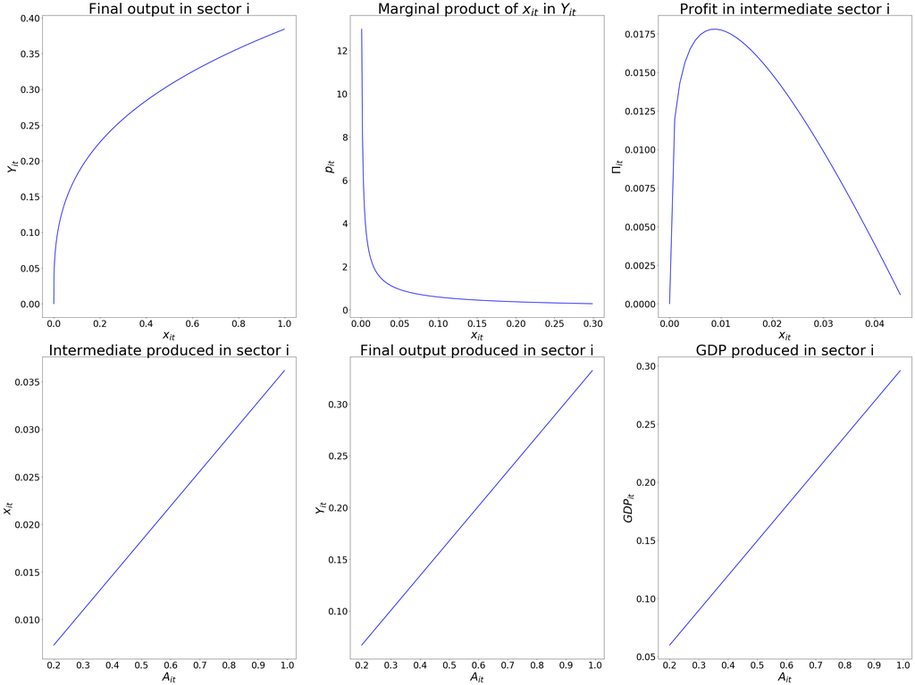

```python
"Code of section I"


"First a function is written that determines output in each sector."

def Y_it(A_it, L, x_it, alpha):
    "Determines output in sector i."
    return ((A_it*L)**(1-alpha))*(x_it**alpha)



"Second, the function determining the price of the intermediate good in sector i is translated into code."

def p_it(alpha, A_it, L, x_it):
    "Determines the price of x_it."
    return alpha*((A_it*L)**(1-alpha))*(x_it**(alpha-1))



"Now a function for price is available, the profit of the monopolist in sector i can be determined."

def profit_it(alpha, A_it, L, x_it):
    "The profit of the intermediate product monopolist i at time t."
    return p_it(alpha, A_it, L, x_it)*x_it - x_it



"profit_it(alpha, A_it, L, x_it) can be optimized such that it returns the optimal amount of intermediate good \
x_it to be produced given the objective of the monopolist to maximize profits."

def x_it(alpha, A_it, L):
    "Determines the optimal quantity  of the intermediate good to be produced in sector i."
    x_it = fminbound(lambda x: -profit_it(alpha, A_it , L, x), 0, 100000000000000000000000)
    ## Setting such a large upper boundary is needed for dealing with large values of A in sections 2 and 3.
    if x_it < 0:
        x_it = 0
    elif profit_it(alpha, A_it, L, x_it) < 0:
        x_it = 0
    else:
        x_it = x_it

    return x_it



"Final output in sector i can now be determined."

def Y_it_optimal(A_it, L, alpha):
    "Determines the final output in sector i given the amount of intermediate good produced."
    return Y_it(A_it, L, x_it(alpha, A_it, L), alpha)



"GDP is computed as the value added over all sectors. The following code computes the part of GDP belonging to\
sector i. Section 3 of this model will extend the GDP computation in a multisector environment."

def GDP_it(alpha, A_it, L):
    "Defines the part in GDP of sector i."
    Y_it = Y_it_optimal(A_it, L, alpha)
    X_it = x_it(alpha, A_it, L)
    return Y_it - X_it






"Plotting the above expressions:"

"In period t, each sector determines how much intermediate good x_it to produce.\
Plotting output in sector i as function of the amount of intermediate good produced in sector i."

range_x_it = np.arange(0, 1, 0.001)
range_Y_it = [Y_it(0.24, 1, x_it, 0.33) for x_it in range_x_it]

plt.figure(figsize=(40,30))

plt.subplot(2, 3, 1)
plt.plot(range_x_it, range_Y_it, '-', color = 'b', linewidth = 2)
plt.xticks(fontsize=28)
plt.yticks(fontsize=28)
plt.title("Final output in sector i", fontsize = 45)
plt.xlabel("$x_{it}$", fontsize = 35)
plt.ylabel("$Y_{it}$", fontsize = 35, rotation = 90)



"Plotting the price of the intermediate good in sector i."

range_x_it = np.arange(0, 0.3, 0.001)
range_p_it = [p_it(0.33, 0.24, 1, x_it) for x_it in range_x_it]

plt.subplot(2, 3, 2)
plt.plot(range_x_it, range_p_it, '-', color = 'b', linewidth = 2)
plt.xticks(fontsize=28)
plt.yticks(fontsize=28)
plt.title("Marginal product of $x_{it}$ in $Y_{it}$", fontsize = 45)
plt.xlabel("$x_{it}$", fontsize = 35)
plt.ylabel("$p_{it}$", fontsize = 35, rotation = 90)



"Plotting the profits of intermediate good sector i."

range_x_it = np.arange(-0.1, 0.045, 0.001)
range_profit_it = [profit_it(0.33, 0.24, 1, x_it) for x_it in range_x_it]

plt.subplot(2, 3, 3)
plt.plot(range_x_it, range_profit_it, '-', color = 'b', linewidth = 2)
plt.xticks(fontsize=28)
plt.yticks(fontsize=28)
plt.title("Profit in intermediate sector i", fontsize = 45)
plt.xlabel("$x_{it}$", fontsize = 35)
plt.ylabel("$\Pi_{it}$", fontsize = 35, rotation = 90)



"Plotting the optimal amount of intermediate good to produce in sector i."

range_A_it = np.arange(0.2, 1, 0.01)
range_x_it = [x_it(0.33, A_it, 1) for A_it in range_A_it]

plt.subplot(2, 3, 4)
plt.plot(range_A_it, range_x_it, '-', color = 'b', linewidth = 2)
plt.xticks(fontsize=28)
plt.yticks(fontsize=28)
plt.title("Intermediate produced in sector i", fontsize = 45)
plt.xlabel("$A_{it}$", fontsize = 35)
plt.ylabel("$x_{it}$", fontsize = 35, rotation = 90)



"Plotting final output produced in sector i."

range_A_it = np.arange(0.2, 1, 0.01)
range_Y_it_optimal = [Y_it_optimal(A_it, 1, 0.33) for A_it in range_A_it]

plt.subplot(2, 3, 5)
plt.plot(range_A_it, range_Y_it_optimal, '-', color = 'b', linewidth = 2)
plt.xticks(fontsize=28)
plt.yticks(fontsize=28)
plt.title("Final output produced in sector i", fontsize = 45)
plt.xlabel("$A_{it}$", fontsize = 35)
plt.ylabel("$Y_{it}$", fontsize = 35, rotation = 90)



"Plotting the absolute contribution of sector i to GDP."

range_A_it = np.arange(0.2, 1, 0.01)
range_GDP_it_optimal = [GDP_it(0.33, A_it, 1) for A_it in range_A_it]

plt.subplot(2, 3, 6)
plt.plot(range_A_it, range_GDP_it_optimal, '-', color = 'b', linewidth = 2)
plt.xticks(fontsize=28)
plt.yticks(fontsize=28)
plt.title("GDP produced in sector i", fontsize = 45)
plt.xlabel("$A_{it}$", fontsize = 35)
plt.ylabel("$GDP_{it}$", fontsize = 35, rotation = 90)



plt.tight_layout()
plt.show()
```

## Section II. - Innovation

This section will focus on the role innovation plays in the development of the productivity paramater $A_{it}$. This can be interpreted as the role innovation plays in the development of the sector's and ultimately economy's stock of technology or alternatively as the development of the quality of intermediate good $x_{it}$. Each sector is characterised by a pool of entrepreneurs who spend final output $Y_{it}$ in R&D and of whom the one with the (most) successful innovation becomes the monopolist in the intermediate good market for that period. Entrepreneurs have the opportunity every period to invest in R&D and thus to improve their product. R&D however is costly and its success is not guaranteed. Each successful innovation will create a new but better version of the product and make all previous versions obsolete.

$\phi(n_{it}) = \lambda n_{it}^\sigma$ is the probability that successful innovation occurs. Not the absolute amount of R&D expenditure matters but the productivity-adjusted expenditure.

$n_{it} = \frac {R_{it}}{A_{it}^*}$ , $n_{it}$ is the R&D expenditure in sector i at time t relative to the target productivity level, $A_{it}^*$, in sector i at time t. The more the entrepreneur spends on R&D, the larger its probability of successful innovation becomes. Yet the larger $A_{it}^*$ becomes, the more complex it is to further improve the product. The probability of innovation thus inversely depends on $A_{it}^*$.

$A_{it}^* = \gamma A_{i, t-1}$ , $A_{it}^*$ represents the productivity parameter in the current period t after successful innovation in the previous period. In case of unsuccessful innovation $A_{it} = A_{i, t-1}$.

The objective of the entrepreneur is assumed to be the optimization of its private benefit of innovation. The entrepreneur therefore chooses its R&D expenditure such that it optimizes its net benefit of innovation. The net benefit of innovation can be represented as: $\phi(\frac {R_{it}}{A_{it}^*})\Pi_{it}^*-R_{it}$ , where $\phi(\frac {R_{it}}{A_{it}^*})$ is the probability of successful innovation and $\Pi_{it}^*$ is the entrepreneur's profit in case of successful innovation and becoming the intermediate good monopolist.

Subsequently, the net benefit maximizing level of R&D expenditure can be substituted back into $n_{it}$ to find the resulting R&D expenditure in sector i relative to the target productivity level, $A_{it}^*$ , we refer to this function as $n$. Similarly we can substitute the optimal level of R&D expenditure into the function defining the probability of innovation, $\lambda (\frac {R_{it}}{A_{it}^*})^\sigma$, this function is referred to as $\mu$.

$n$ and $\mu$ will be proven to be independent of the sectors' starting value of $A_{i}$ and the previous period $A_{i}$ level of technology. The intuition behind this is that higher profits accompanying successful innovation in more advanced sectors are offset 1:1 by increasing cost of innovation the more advanced a sector is. This property of a constant $\mu$ allows to easily determine the aggregate growth rate of the economy in section three.

### Variable:

- $A_{initial}$ = The initial level of technology from which the economy starts off. In section two this can be interpreted as $A_{i,t-1}$.

### Parameters:

- $\lambda$ Reflects the productivity of the research sector. In the analysis this parameter is set equal to 1.5
- $\sigma$ An elasticity between 0 and 1 of the Cobb-Douglas function to guarantee a positive but decreasing marginal product of generating innovations. It thus reflects the decreasing returns to R&D. In the analysis this parameter is set equal to 0.4
- $\gamma$ Illustrates the size of an innovation and should be larger than 1. It thus can be interpreted as the average product quality improvement per innovation. In the analysis this parameter is set equal to 1.2

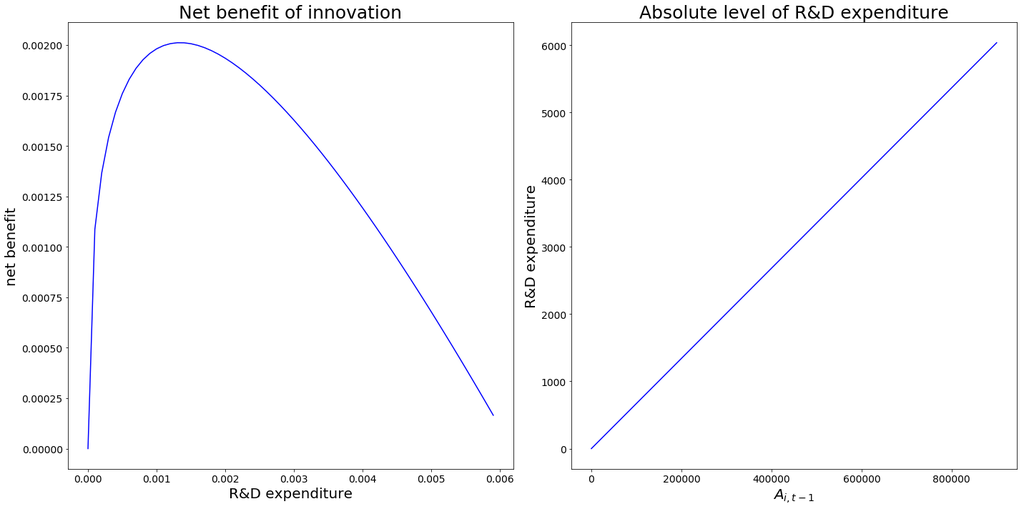

```
n with $A_{i,t-1}$ = 0.2     :  0.00558
n with $A_{i,t-1}$ = 2.0     :  0.00559
n with $A_{i,t-1}$ = 5.0     :  0.00559
n with $A_{i,t-1}$ = 300     :  0.00559
n with $A_{i,t-1}$ = 30.000  :  0.00559
mu with $A_{i,t-1}$ = 0.2    :  0.18832
mu with $A_{i,t-1}$ = 2.0    :  0.18839
mu with $A_{i,t-1}$ = 5.0    :  0.18839
mu with $A_{i,t-1}$ = 300    :  0.18839
mu with $A_{i,t-1}$ = 30.000 :  0.18839
```

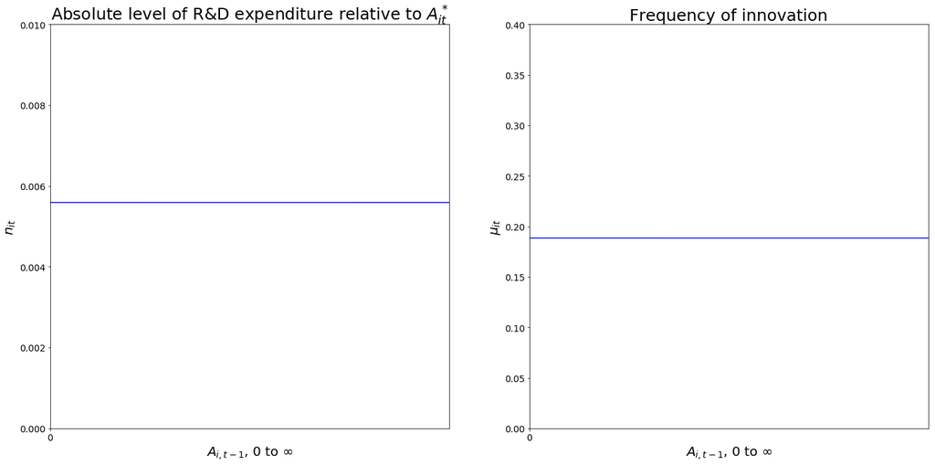

```python
"Code of section II"

"Section 2 only uses two periods, A_it and A_it_min1. This can be done because only the relative distance\
between two levels of A is relevant for the analysis in this section. Evidence of this will be provided towards\
the end of this section."



"Translating the math into code yields:"

def A_it_star(gamma, A_it_min1):
    "The target productivity level next period for firm i if R&D turned to be successful."
    return gamma*A_it_min1

def prob_inno(lam, R_it, gamma, A_it_min1, sigma): ## lam = lambda
    "The probability of innovation, or alternatively interpreted, the frequency of innovation."
    return lam*((R_it / A_it_star(gamma, A_it_min1))**sigma)

def net_benefit_inno(lam, R_it, gamma, A_it_min1, sigma, alpha, A_it, L):
    "The net benefit of innovation."
    return prob_inno(lam, R_it, gamma, A_it_min1, sigma)*profit_it(alpha, A_it, L, x_it(alpha, A_it, L)) - R_it



"The entrepreneur will optimize its private benefit of innovation by means of choosing its level of R&D expenditure."

def R_it_optimal(lam, gamma, A_it_min1, sigma, alpha, A_it, L):
    "The for the entrepreneur optimal level of R&D expenditure."
    R_it = fminbound(lambda x: -net_benefit_inno(lam, x, gamma, A_it_min1, sigma, alpha, A_it, L), 0, 100000) ## Setting such a large upper boundry is needed for dealing with very large values of "A".
    if R_it < 0:
        R_it = 0 ## No negative levels of R&D expenditure are possible.
    elif net_benefit_inno(lam, R_it, gamma, A_it_min1, sigma, alpha, A_it, L) < 0:
        R_it = 0 ## R&D expenditure will not take place when the entrepreneur does not gain benefit from spending on R&D.
    else:
        R_it = R_it

    return R_it





"Plotting the net benefit of innovation and the for the entrepreneur optimal level of R&D expenditure:"


"Plotting the net benefit of innovation as a function of R&D expenditure."

plt.figure(figsize=(20,10))

range_R_it = np.arange(-0.1, 0.006, 0.0001)
range_net_benefit_inno = [net_benefit_inno(1.5, R_it, 1.2, 0.2, 0.4, 0.33, 0.24, 1) for R_it in range_R_it]

plt.subplot(1, 2, 1)
plt.plot(range_R_it, range_net_benefit_inno, '-', color = 'b', linewidth = 1.5)
plt.xticks(fontsize=14)
plt.yticks(fontsize=14)
plt.title("Net benefit of innovation", fontsize = 25)
plt.xlabel("R&D expenditure", fontsize = 20)
plt.ylabel("net benefit", fontsize = 20, rotation = 90)



"Plotting the optimal R&D expenditure as a function the previous period's level of technology."

"A_it can only take two values:\
-In case of no innovation, A_i in the current period is equal to A_i in the previous period.\
-In case of innovation, A_i in the current period is equal to gamma times the level of A_i in the previous period."



range_A_it_min1 = np.arange(1, 1000000, 100000)
## When a larger upper boundary is desired, it might be necessary to adapt the upper boundaries of the earlier optimizations.

range_R_it_optimal = [R_it_optimal(1.5, 1.2, A_it_min1, 0.4, 0.33, A_it_star(1.2, A_it_min1), 1) for A_it_min1 in range_A_it_min1]

plt.subplot(1, 2, 2)
plt.plot(range_A_it_min1, range_R_it_optimal, '-', color = 'b', linewidth = 1.5)
plt.xticks(fontsize=14)
plt.yticks(fontsize=14)
plt.title("Absolute level of R&D expenditure", fontsize = 25)
plt.xlabel("$A_{i,t-1}$", fontsize = 20)
plt.ylabel("R&D expenditure", fontsize = 20, rotation = 90)

plt.tight_layout()
plt.show()




"To find the R&D expenditure in sector i relative to the target productivity level of sector i, \
the following expression for n is introduced."

def n(lam, gamma, A_it_min1, sigma, alpha, A_it, L):
    "The optimal level of R&D expenditure in sector i relative to the target productivity level of sector i."
    return R_it_optimal(lam, gamma, A_it_min1, sigma, alpha, A_it, L) / A_it_star(gamma, A_it_min1)



"The optimal level of R&D expenditure can be substituted into the expression for the probability of innovation, \
which was formulated earlier, and doing so will yield the following expression for mu."

def mu(lam, gamma, A_it_min1, sigma, alpha, A_it, L):
    "The probability of innovation but with it incorporated the for the entrepreneur optimal level of R&D expenditure."
    x = prob_inno(lam, R_it_optimal(lam, gamma, A_it_min1, sigma, alpha, A_it, L), gamma, A_it_min1, sigma)
    if x > 1: ## Probabilities cannot become larger than 1 or smaller than 0.
        x = 1
    elif x < 0:
        x = 0
    else:
        x = x
    return x


"The claim at the top of this section can now be proven. Using arbitrary values for A_it_min1 and adapting A_it \
correspondingly (in case of innovation, A_it = gamma*A_it_min1), shows that both n and mu are constant\
and thus independent of the previous level of technology."

print("n with $A_{i,t-1}$ = 0.2     : ", "{0:.5f}".format(n(1.5, 1.2, 0.2, 0.4, 0.33, 0.24, 1)))
print("n with $A_{i,t-1}$ = 2.0     : ", "{0:.5f}".format(n(1.5, 1.2, 2, 0.4, 0.33, 2.4, 1)))
print("n with $A_{i,t-1}$ = 5.0     : ", "{0:.5f}".format(n(1.5, 1.2, 5, 0.4, 0.33, 6, 1)))
print("n with $A_{i,t-1}$ = 300     : ", "{0:.5f}".format(n(1.5, 1.2, 300, 0.4, 0.33, 360, 1)))
print("n with $A_{i,t-1}$ = 30.000  : ", "{0:.5f}".format(n(1.5, 1.2, 30000, 0.4, 0.33, 36000, 1)))

print("mu with $A_{i,t-1}$ = 0.2    : ", "{0:.5f}".format(mu(1.5, 1.2, 0.2, 0.4, 0.33, 0.24, 1)))
print("mu with $A_{i,t-1}$ = 2.0    : ", "{0:.5f}".format(mu(1.5, 1.2, 2, 0.4, 0.33, 2.4, 1)))
print("mu with $A_{i,t-1}$ = 5.0    : ", "{0:.5f}".format(mu(1.5, 1.2, 5, 0.4, 0.33, 6, 1)))
print("mu with $A_{i,t-1}$ = 300    : ", "{0:.5f}".format(mu(1.5, 1.2, 300, 0.4, 0.33, 360, 1)))
print("mu with $A_{i,t-1}$ = 30.000 : ", "{0:.5f}".format(mu(1.5, 1.2, 30000, 0.4, 0.33, 36000, 1)))




"Plotting n and mu:"

range_A_it_min1 = np.arange(1, 1000000, 100000)

range_n = [n(1.5, 1.2, A_it_min1, 0.4, 0.33, A_it_star(1.2, A_it_min1), 1) for A_it_min1 in range_A_it_min1]

range_mu = [mu(1.5, 1.2, A_it_min1, 0.4, 0.33, A_it_star(1.2, A_it_min1), 1) for A_it_min1 in range_A_it_min1]


plt.figure(figsize=(20,10))

"Plotting n"
plt.subplot(1, 2, 1)
plt.plot(range_A_it_min1, range_n, '-', color = 'b', linewidth = 1.5)
plt.xlim(1,100000)
plt.xticks(np.arange(0,1000000, step = 1000000), fontsize=14)
plt.ylim(0,0.01)
plt.yticks(fontsize=14)
plt.title("Absolute level of R&D expenditure relative to ${A_{it}^*}$", fontsize = 25)
plt.xlabel("$A_{i,t-1}$, 0 to $\infty$", fontsize = 20)
plt.ylabel("$n_{it}$", fontsize = 20, rotation = 90)

"Plotting mu"
plt.subplot(1, 2, 2)
plt.plot(range_A_it_min1, range_mu, '-',  color = 'b', linewidth = 1.5)
plt.xlim(1,100000)
plt.xticks(np.arange(0,1000000, step = 1000000), fontsize=14)
plt.ylim(0,0.4)
plt.yticks(fontsize=14)
plt.title("Frequency of innovation", fontsize = 25)
plt.xlabel("$A_{i,t-1}$, 0 to $\infty$", fontsize = 20)
plt.ylabel("$\mu_{it}$", fontsize = 20, rotation = 90)

plt.tight_layout()
plt.show()
```

### Tweaking Interface

```python
"Tweaking Interface"

"Choose parameter values here for all following computations."
def LAMBDA():
    return 1.5 ## Productivity of the research sector. >=1

def GAMMA():
    return 1.2 ## Size of an innovation/Average product quality improvement per innovation. >1

def SIGMA():
    return 0.4 ## Decreasing returns to R&D. [0,1]

def ALPHA():
    return 0.33 ## Share of intermediate products in final output. [0,1]

def L():
    return 1.0 ## Size of the workforce. >0

def A_INITIAL():
    return 2.0 ## Initial value of technology with which each sector starts. >0




def A_IT_STAR():
    "Target productivity level next period."
    return GAMMA()*A_INITIAL()

def MU():
    "The value of mu with which the analysis will work."
    return mu(LAMBDA(), GAMMA(), A_INITIAL(), SIGMA(), ALPHA(), A_IT_STAR(), L())

def N():
    "The value of n belonging to the analysis."
    return n(LAMBDA(), GAMMA(), A_INITIAL(), SIGMA(), ALPHA(), A_IT_STAR(), L())

def MATHEMATICAL_GROWTH_RATE():
    "Benchmark for the success of the simulation based on the math underlying the model."
    return MU()*(GAMMA()-1) ## See section 3 for derivation.

print("N = ", "{0:.5f}".format(N()))
print("MU =", "{0:.5f}".format(MU()))
print("MATHEMATICAL GROWTH RATE =", "{0:.5f}".format(MATHEMATICAL_GROWTH_RATE()))
```

```
N =  0.00559
MU = 0.18839
MATHEMATICAL GROWTH RATE = 0.03768
```

## Section III. - Long-Term Growth

Section one already graphically showed $Y_{i,t,optimal}$ to be proportional to $A_{it}$. This can however also be seen from $Y_{i,t,optimal}$ only being dependent on the variable $A_{it}$. The sector's growth rate is therefore proportional to the growth rate of $A_{it}$.

$$g_{(i)t} = \frac {A_{it} - A_{i,t-1}}{A_{i,t-1}}$$

The economy's aggregate growth rate is dependent on the average growth rate in the stock of technology across the various sectors. In the analysis it is assumed that all sectors are equally large and thus receive the same weight when calculating the average growth. Although this assumption is not explicitly needed as all sectors face the same probability ($\mu$) and size ($\gamma$) of innovation.

Because the probability and size of innovation are the same across all sectors, the initial model relies on the law of large numbers to determine $g_{t}$. That is, when the number of sectors in the economy is large enough, the fraction of sectors that innovate each period approaches $\mu$ and thus the economy wide $A_{t}$ will grow with a probability of $\mu$. This leads to the following expression for $A_{t}$:

$$A_{t} = \mu \gamma A_{t-1} + (1 - \mu) A_{t-1}$$

Substituting this expression for $A_{t}$ into $g_{t}$ yields the economy's growth rate $g$ and can be rewritten into:

$$g = \mu(\gamma - 1)$$

To prove the above claim about $g$, while avoiding the law of large numbers, we introduce a binominal trial to simulate the growth path of each sector $A_{it}$. This is done for ten sectors and 250 periods. To capture the cases in which sectors fail to innovate in the first period, it is assumed that all sectors start with the same level of initial technology. This value is set to 2 . The levels of technology are summed across sectors for each period and consecutively the economy's aggregate growth rate in $A_{t}$ is calculated for each period. Of these growth rates the unweighted average is taken to find $g$. The computations are repeated for $Y$ and $GDP$ to complete the proof that all three are proportional and thus grow at the same rate.

```python
"Code of section III"

"The following code creates by means of a binominal trial the development of sector-1's A over 250 periods."
## Be careful with setting many periods and a relatively high value for gamma, "A" will get very large and earlier
## set boundaries might need to be adapted accordingly.

np.random.seed(0)
random_numbers = np.random.random(249) ## 249 periods + the starting period makes 250 periods.
innovation_happens = random_numbers <= MU() ## The binominal component.

## Initiating the sector's (empty) list with the common starting value of A_INITIAL across all sectors,
## this is needed in case innovation does not happen in the second period.
A_1t = [A_INITIAL()]

for x in innovation_happens:
    if x == True:
         A_1t.append(GAMMA()*A_1t[-1])
    else:
         A_1t.append(A_1t[-1])

def growth_path_1():
     return A_1t
print("Number of periods:", len(A_1t))
print("Growth path of sector-1's A for the first ten periods:", growth_path_1()[:10])



"To create more sectors the above binominal trial is copy-pasted nine times\
but with different random numbers each time. As such an economy is created comprising ten sectors."

"Sector 2"
np.random.seed(1)
random_numbers = np.random.random(249)
innovation_happens = random_numbers <= MU()

A_2t = [A_INITIAL()]

for x in innovation_happens:
    if x == True:
         A_2t.append(GAMMA()*A_2t[-1])
    else:
         A_2t.append(A_2t[-1])

def growth_path_2():
     return A_2t
print("Growth path of sector-2's A for the first ten periods:", growth_path_2()[:10])


"Sector 3"
np.random.seed(2)
random_numbers = np.random.random(249)
innovation_happens = random_numbers <= MU()

A_3t = [A_INITIAL()]

for x in innovation_happens:
    if x == True:
         A_3t.append(GAMMA()*A_3t[-1])
    else:
         A_3t.append(A_3t[-1])

def growth_path_3():
     return A_3t
print("Growth path of sector-3's A for the first ten periods:", growth_path_3()[:10])


"Sector 4"
np.random.seed(3)
random_numbers = np.random.random(249)
innovation_happens = random_numbers <= MU()

A_4t = [A_INITIAL()]

for x in innovation_happens:
    if x == True:
         A_4t.append(GAMMA()*A_4t[-1])
    else:
         A_4t.append(A_4t[-1])

def growth_path_4():
     return A_4t
print("Growth path of sector-4's A for the first ten periods:", growth_path_4()[:10])


"Sector 5"
np.random.seed(4)
random_numbers = np.random.random(249)
innovation_happens = random_numbers <= MU()

A_5t = [A_INITIAL()]

for x in innovation_happens:
    if x == True:
         A_5t.append(GAMMA()*A_5t[-1])
    else:
         A_5t.append(A_5t[-1])

def growth_path_5():
     return A_5t
print("Growth path of sector-5's A for the first ten periods:", growth_path_5()[:10])


"Sector 6"
np.random.seed(5)
random_numbers = np.random.random(249)
innovation_happens = random_numbers <= MU()

A_6t = [A_INITIAL()]

for x in innovation_happens:
    if x == True:
         A_6t.append(GAMMA()*A_6t[-1])
    else:
         A_6t.append(A_6t[-1])

def growth_path_6():
     return A_6t
print("Growth path of sector-6's A for the first ten periods:", growth_path_6()[:10])


"Sector 7"
np.random.seed(6)
random_numbers = np.random.random(249)
innovation_happens = random_numbers <= MU()

A_7t = [A_INITIAL()]

for x in innovation_happens:
    if x == True:
         A_7t.append(GAMMA()*A_7t[-1])
    else:
         A_7t.append(A_7t[-1])

def growth_path_7():
     return A_7t
print("Growth path of sector-7's A for the first ten periods:", growth_path_7()[:10])


"Sector 8"
np.random.seed(7)
random_numbers = np.random.random(249)
innovation_happens = random_numbers <= MU()

A_8t = [A_INITIAL()]

for x in innovation_happens:
    if x == True:
         A_8t.append(GAMMA()*A_8t[-1])
    else:
         A_8t.append(A_8t[-1])

def growth_path_8():
     return A_8t
print("Growth path of sector-8's A for the first ten periods:", growth_path_8()[:10])


"Sector 9"
np.random.seed(8)
random_numbers = np.random.random(249)
innovation_happens = random_numbers <= MU()

A_9t = [A_INITIAL()]

for x in innovation_happens:
    if x == True:
         A_9t.append(GAMMA()*A_9t[-1])
    else:
         A_9t.append(A_9t[-1])

def growth_path_9():
     return A_9t
print("Growth path of sector-9's A for the first ten periods:", growth_path_9()[:10])


"Sector 10"
np.random.seed(9)
random_numbers = np.random.random(249)
innovation_happens = random_numbers <= MU()

A_10t = [A_INITIAL()]

for x in innovation_happens:
    if x == True:
         A_10t.append(GAMMA()*A_10t[-1])
    else:
         A_10t.append(A_10t[-1])

def growth_path_10():
     return A_10t
print("Growth path of sector-10's A for the first ten periods:", growth_path_10()[:10])
```

```
Number of periods: 250
Growth path of sector-1's A for the first ten periods: [2.0, 2.0, 2.0, 2.0, 2.0, 2.0, 2.0, 2.0, 2.0, 2.0]
Growth path of sector-2's A for the first ten periods: [2.0, 2.0, 2.0, 2.4, 2.4, 2.88, 3.456, 4.1472, 4.1472, 4.1472]
Growth path of sector-3's A for the first ten periods: [2.0, 2.0, 2.4, 2.4, 2.4, 2.4, 2.4, 2.4, 2.4, 2.4]
Growth path of sector-4's A for the first ten periods: [2.0, 2.0, 2.0, 2.0, 2.0, 2.0, 2.0, 2.4, 2.4, 2.88]
Growth path of sector-5's A for the first ten periods: [2.0, 2.0, 2.0, 2.0, 2.0, 2.0, 2.0, 2.0, 2.4, 2.4]
Growth path of sector-6's A for the first ten periods: [2.0, 2.0, 2.0, 2.0, 2.0, 2.0, 2.0, 2.0, 2.0, 2.0]
Growth path of sector-7's A for the first ten periods: [2.0, 2.0, 2.0, 2.0, 2.4, 2.88, 2.88, 2.88, 2.88, 2.88]
Growth path of sector-8's A for the first ten periods: [2.0, 2.4, 2.4, 2.4, 2.4, 2.4, 2.4, 2.4, 2.88, 2.88]
Growth path of sector-9's A for the first ten periods: [2.0, 2.0, 2.0, 2.0, 2.0, 2.0, 2.4, 2.4, 2.4, 2.4]
Growth path of sector-10's A for the first ten periods: [2.0, 2.4, 2.4, 2.4, 2.88, 3.456, 3.456, 3.456, 3.456, 4.1472]
```

```python
"We now have an economy comprising ten sectors. To obtain the economy's aggregate level of A, \
each element of the list needs to be summed across lists."

def A_economy():
    return [sum(pair) for pair in zip(growth_path_1(), growth_path_2(), growth_path_3(),growth_path_4()\
                     ,growth_path_5(),growth_path_6(),growth_path_7(),growth_path_8(),growth_path_9(),\
                    growth_path_10())]
print("Number of periods:", len(A_economy()))
print("Aggregate level of technology for the first ten periods:", A_economy()[:10])
```

```
Number of periods: 250
Aggregate level of technology for the first ten periods: [20.0, 20.799999999999997, 21.2, 21.599999999999998, 22.48, 24.016, 24.991999999999997, 26.083199999999998, 26.963199999999997, 28.1344]
```

```python
"Calculating the average growth rate of the economy's A per period."

growth_rates_A = []

for entry in range(1,len(A_economy())):
    rate = ((A_economy()[entry] - A_economy()[entry-1]) * 100.0 / A_economy()[entry-1])
    growth_rates_A.append(rate)
print("The economy's percentage growth rate of A for the first ten periods:", growth_rates_A[:10])



"Calculating the economy's average growth rate of A across all periods."

def average_growth_rate_A_economy():
    return sum(growth_rates_A)/len(growth_rates_A)
print("The economy's average growth rate of A across all periods is","{0:.5f}".format(average_growth_rate_A_economy()),"percent.")
```

```
The economy's percentage growth rate of A for the first ten periods: [3.999999999999986, 1.9230769230769336, 1.886792452830182, 4.074074074074086, 6.832740213523122, 4.063957361758824, 4.366197183098595, 3.373819163292844, 4.343698077379549, 1.421747042766146]
The economy's average growth rate of A across all periods is 3.77260 percent.
```

```python
"To prove that the growth rate of Y is proportional to the growth rate of A, first the economy's ouput\
is determined in each of the periods."

"Because all sectors have the same L and alpha, the function Y_it_optimal can directly be used\
to determine the economy's output. This is identical to summing over each sectors' output."

Y_economy = []

def Y(L):
    for entry in tqdm(A_economy()):
        Y_economy.append(Y_it_optimal(entry, L, ALPHA()))
Y(L())


"Calculating the average growth rate of the economy's Y per period."

growth_rates_Y_economy = []

for entry in range(1,len(Y_economy)):
    rate = ((Y_economy[entry] - Y_economy[entry-1]) * 100.0 / Y_economy[entry-1])
    growth_rates_Y_economy.append(rate)



"Calculating the economy's average growth rate of Y across all periods."

def average_growth_rate_Y_economy():
    return sum(growth_rates_Y_economy)/len(growth_rates_Y_economy)
print("The economy's average growth rate in Y across all periods is", "{0:.5f}".format(average_growth_rate_Y_economy()) ,"percent. \
This indeed is equal to the average growth rate in A across all periods.")
```

```
The economy's average growth rate in Y across all periods is 3.77260 percent. This indeed is equal to the average growth rate in A across all periods.
```

```python
"Doing the above once more but now for GDP. This will prove GDP growth to be proportional to growth in Y."

gdp = []

def GDP(L):
    for entry in tqdm(A_economy()):
        gdp.append(GDP_it(ALPHA(), entry, L)) ## GDP_it(alpha, entry, L) can be used due to symmetry in L and alpha across sectors.

GDP(L())




"Calculating the average growth rate of GDP per period."

growth_rates_gdp = []

for entry in range(1,len(gdp)):
    rate = ((gdp[entry] - gdp[entry-1]) * 100.0 / gdp[entry-1])
    growth_rates_gdp.append(rate)



"Calculating the economy's average growth rate of GDP across all periods."

def average_growth_rate_GDP():
    return sum(growth_rates_gdp)/len(growth_rates_gdp)
print("The economy's average growth rate of GDP across all periods is", "{0:.5f}".format(average_growth_rate_GDP()), "percent.\
 This is equal to the average growth rate of Y across all periods.")
```

```
The economy's average growth rate of GDP across all periods is 3.77260 percent. This is equal to the average growth rate of Y across all periods.
```

## Section IV. - Sensitivity Analysis

The model has proven that long-run economic growth is driven by innovation and in particular the process of creative destruction. This makes the model well suited for analysing how an economy's growth performance will vary with its proximity to the technological frontier and to what extent the economy will tend to converge to this frontier. Moreover, the model will prove to be relevant in guiding policy discussions aiming at either sustaining or enhancing growth.

This section performs a sensitivity analysis where each parameter is decreased by 10% to assess the relative impact on the growth rates. Changing parameters ceteris paribus illustrates that $\gamma$ has no effect on $n$ and $\mu$ but does significantly affect $g$. This is due to $A_{it}^*$ having no effect on $n$ and $\mu$ (see section two), while $A$ accumulates with factor $\gamma$, and thus has much influence there. $A$ has no effect on $n$, $\mu$ and $g$, this is in line with $A_{it}^*$ having no effect on growth. $\alpha$ barely has an effect on $n$, $\mu$ and $g$. Its negative relation with growth can be explained from the share intermediates take in final good production. Changes in the work force have little effect either, but give the expected result of a growth rate decrease (scale effect). Only $\sigma$ and $\lambda$ prove to be other parameters that substantially influence the growth rate. $\lambda$ is the productivity of the research sector and high values as such directly contribute to the speed at which new ideas are created. A stronger effect is found in $\sigma$ which represents the decreasing returns to research. Highly innovating countries experience the downside of this already for years. [Bloom, Jones, Reenen and Webb (2017)](https://ideas.repec.org/p/red/sed017/566.html) for instance show that despite the effective number of researchers increasing drastically over the recent decades, total factor productivity remained fairly constant in the US. This suggests that new ideas are becoming ever more difficult to find as technology progresses and calls for new innovative ways to keep productivity levels up. Open access journals and increasing access to education have been named but addressing the issue will remain challenging future policymakers.

| Parameter | Baseline | 10% decrease | $n$ | $\mu$ | Growth rate predicted | Growth rate mathematical |
| --- | --- | --- | --- | --- | --- | --- |
| $\lambda$ | 1.5 | 1.35 | 0.00469 | 0.15805 | 3.16555% | 3.161% |
| $\sigma$ | 0.4 | 0.36 | 0.00656 | 0.24553 | 4.82715% | 4.911% |
| $\gamma$ | 1.2 | 1.08 | 0.00559 | 0.18838 | 1.52811% | 1.507% |
| $\alpha$ | 0.33 | 0.297 | 0.00567 | 0.18953 | 3.79185% | 3.791% |
| **Variable** |  |  |  |  |  |  |
| $A_{initial}$ | 2.0 | 1.8 | 0.00559 | 0.18838 | 3.77260% | 3.768% |
| $L$ | 1.0 | 0.9 | 0.00469 | 0.17561 | 3.47033% | 3.512% |
| **At baseline:** |  |  | 0.00559 | 0.18839 | 3.77260% | 3.768% |

#### Remark:

The model performs less well for very small values of $A$ due to rounding errors. On the other hand, dealing with very large values of $A$ becomes problematic too because of the chosen boundary limitations in the optimisations of section one and two, these can be extended. Yet for the speed at which the notebook runs, these boundaries are not set to their maximum possible value.

## Conclusion

The model has proven that long term economic growth is proportional and entirely dependent upon the advancement in technology. Moreover, the multisector component of the model has made the frequency of innovation stable and aggregate growth rate no longer random. Enabling fast and efficient exit and turnover of firms proved to be key for economic growth, the model therefore calls for far-reaching labour and product market mobility. The results presented here give important insights for growth economists whether in academia or a professional environment and are more applicable to developed countries.

An issue of the model as presented here is that the parameter values were set arbitrarily. Despite the direction and relative impact of parameter changes having been revealed, it would prove interesting to estimate these empirically. Calibrating these however is beyond the scope of this assignment and therefore left as a possible extension. Another interesting extension of the model would be the incorporation of capital into the production function. Evidence from [growth accounting](https://www.sciencedirect.com/science/article/pii/S1574004816000033) and [Piketty and Zucman (2014)](https://academic.oup.com/qje/article/129/3/1255/1818714?searchresult=1) highlights the importance of capital accumulation for growth but this simple version of the Schumpeter model disregarded capital entirely. Changing the role of intermediates from perishable into durable goods would be one strategy to do this.

Lastly, a major externality in the amount of R&D undertaken has to be mentioned. The model proved innovators to only optimise their private benefit of innovation. By society as a whole however, it would be desired if more R&D was undertaken and has to be taken into account when setting growth policies.